# `R` basics with *The Law of The Census*

Programming Module 1 - Math Prefresher 2017

Connor Jerzak and Shiro Kuriwaki

2017-08-16

# Where are we? Where are we headed?

Up till now, you should have covered:

- The tutorial assignment at http://tryr.codeschool.com/

Today we’ll cover:

- Counting.
- Visualization.
- Data Wrangling
- Objects and Classes.
- Function and Packages

# Check your understanding

- How do you read in a spreadsheet (`csv`) into R?
- How do you count the number of observations for a given category?
- How do you make a barplot, in base-R and in ggplot?
- What is the difference between a data frame and a matrix?
- What are three ways to extract a single variable from a data frame?
- How would you identify a class or type of an object?
- How do you define a new function?

# Motivation

In this module, let’s jump into using the basic functions of R from an actual Census.

Why care about the Census? The Census is one of the fundamental acts of a government. See the Law Review article by [Persily (2011)](http://cardozolawreview.com/Joomla1.5/content/32-3/Persily.32-3.pdf), “The Law of the Census”[^1]. The Census is government’s primary tool for apportionment (allocating seats to districts), appropriations (allocating federal funding), and tracking demographic change. See[^2] for example [Hochschild and Powell (2008)](https://dash.harvard.edu/bitstream/handle/1/3153295/hoschschild_racialreorganization.pdf?sequence=2) on how the categorizations of race in the Census during 1850-1930.

```r
library(dplyr)
library(readr)
library(scales)
library(forcats)
library(ggplot2)
```

# Read data

The first of line code you will write is often to read in data. Here, let’s read in a subset of the 2010 Census. This is a 0.01 percent random sample of the entire U.S. Census.

```r
cen10 <- read_csv("input/usc2010_001percent.csv", col_types = cols())
```

The data comes from IPUMS[^3], a great source to extract and analyze Census and Census-conducted survey (ACS, CPS) data.

What does this data look like?

```r
cen10
```

```
## # A tibble: 30,871 x 13
##     year  serial pernum                   region         state countyfips
##    <int>   <int>  <int>                    <chr>         <chr>      <int>
##  1  2010 8801316      4 Middle Atlantic Division      New York          0
##  2  2010 9800859      1  East North Central Div.          Ohio        103
##  3  2010 8685036      1        Mountain Division        Nevada          3
##  4  2010 6350851      3  East North Central Div.      Michigan          0
##  5  2010 6150669      2  South Atlantic Division      Maryland         33
##  6  2010 8102175      1     New England Division New Hampshire          0
##  7  2010 4057665      1  West North Central Div.          Iowa          0
##  8  2010 7029004      2  West North Central Div.      Missouri          0
##  9  2010 8162406      2 Middle Atlantic Division    New Jersey          3
## 10  2010 1117846      3         Pacific Division    California         37
## # ... with 30,861 more rows, and 7 more variables: city <chr>,
## #   cpuma0010 <int>, sex <chr>, age <int>, race <chr>, hhtype <chr>,
## #   relate <chr>
```

# Counting

How many people are in your sample. Three ways to count:

```r
nrow(cen10)
```

```
## [1] 30871
```

```r
dim(cen10)
```

```
## [1] 30871    13
```

```r
length(cen10$year)
```

```
## [1] 30871
```

Multiply this number by the inverse of the sample proportion. Does it equal the total population of the U.S. in 2010[^4]?

```r
nrow(cen10)*100*100
```

```
## [1] 308710000
```

This and all subsequent tasks involve manipulating and summarizing data, sometimes called “wrangling”. There are at least two approaches, “base-R” and “tidyverse functions”. The tidyverse functions are add-ons that programmers have built, and appears to be popular.

# Tabulating

Here are two ways to count by group, or to tabulate.

Use the `table` function

```r
table(cen10$race)
```

```
##
## American Indian or Alaska Native                      Black/Negro
##                              295                             4013
##                          Chinese                         Japanese
##                              354                               77
##  Other Asian or Pacific Islander                  Other race, nec
##                             1129                             1839
##        Three or more major races                  Two major races
##                               88                              869
##                            White
##                            22207
```

With tidyverse, use `group_by` to group by a variable, and then `summarize` to count.

```r
cen10 %>%
  group_by(race) %>%
  summarize(count = n())
```

```
## # A tibble: 9 x 2
##                               race count
##                              <chr> <int>
## 1 American Indian or Alaska Native   295
## 2                      Black/Negro  4013
## 3                          Chinese   354
## 4                         Japanese    77
## 5  Other Asian or Pacific Islander  1129
## 6                  Other race, nec  1839
## 7        Three or more major races    88
## 8                  Two major races   869
## 9                            White 22207
```

These `tidyverse` commands from the `dplyr` package are newer and not built-in, but they are one of the increasingly more popular ways to wrangle data.

- 80 percent of your data wrangling needs might be doable with these basic `dplyr` functions: `select`, `mutate`, `group_by`, `summarize`, and `arrange`.
- These verbs roughly correspond to the same commands in SQL, another important language in data science.
- The `%>%` symbol is a pipe. It takes the thing on the left side and pipes it down to the function on the right side. `cen10 %>% group_by(race)` means take `cen10` and pass it on to the function `group_by`, which will group observations by race. Passing that (`%>%`) to `summarize(count = n())` means to then summarize the grouped output by the variable `count`, which we define by the number of rows `n()`.

# Visualization

Visualizing data is the key part of communication; good data viz gets the point across[^5].

Two prevalent ways of making graphing are referred to as “base-R” and “ggplot”.

## base R

“Base-R” graphics are graphics that are made with R’s default graphics commands. First, let’s assign our tabulation to an object, call it `tab_race`

```r
tab_race <- table(cen10$race)
```

Then put it in the `barplot()` function

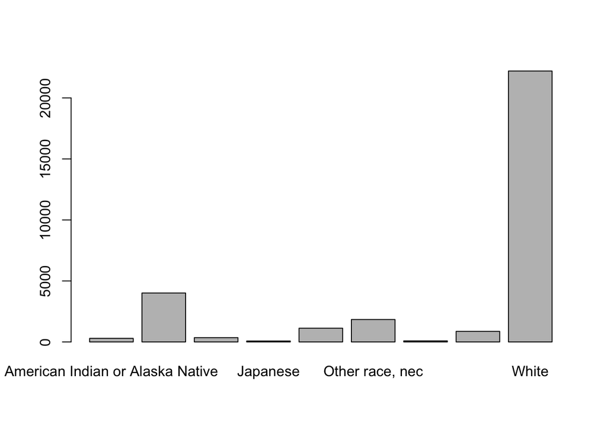

```r
barplot(tab_race)
```

## ggplot

A popular alternative a `ggplot` graphics. `gg` stands for grammar of graphics by Hadley Wickham, and it has a new semantics of explaining graphics in R. Again, first let’s set up the data.

Let’s group and count first, like we just did.

```r
grp_race <- group_by(cen10, race) %>%
  summarize(count = n())
```

We will now plot this grouped set of numbers. The `ggplot()` function takes two main arguments, `data` and `aes`.

1. First enter a single dataframe from which you will draw a plot.
2. Then enter the `aes`, or aesthetics. This defines which variable in the data the plotting functions should take for pre-set dimensions in graphics. The dimenions `x` and `y` are the most important. We will assign `race` and `count` to them, respectively,
3. After you close `ggplot()` .. add **layers** by the plus sign. A `geom` is a layer of graphical representation, for example `geom_histogram` renders a histogram, `geom_point` renders a scatter plot. For a barplot, we can use `geom_col()`

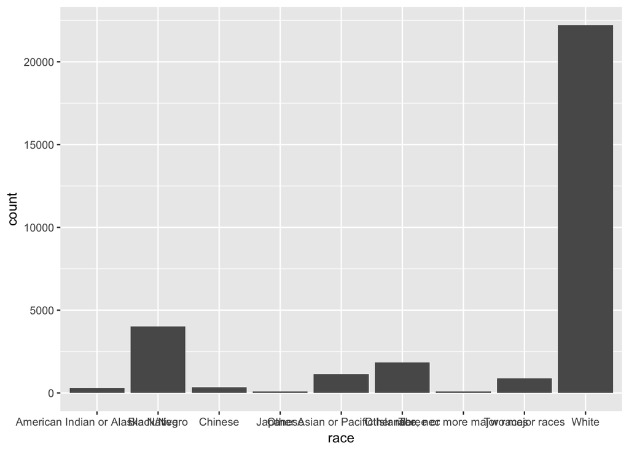

```r
ggplot(data = grp_race, aes(x = race, y = count)) + geom_col()
```

## Improving your graphics

Adjusting your graphics to make the point clear is an important skill. Here is an example of showing the same numbers but with a different design, in a way that aims to maximize the data-to-ink ratio[^6]

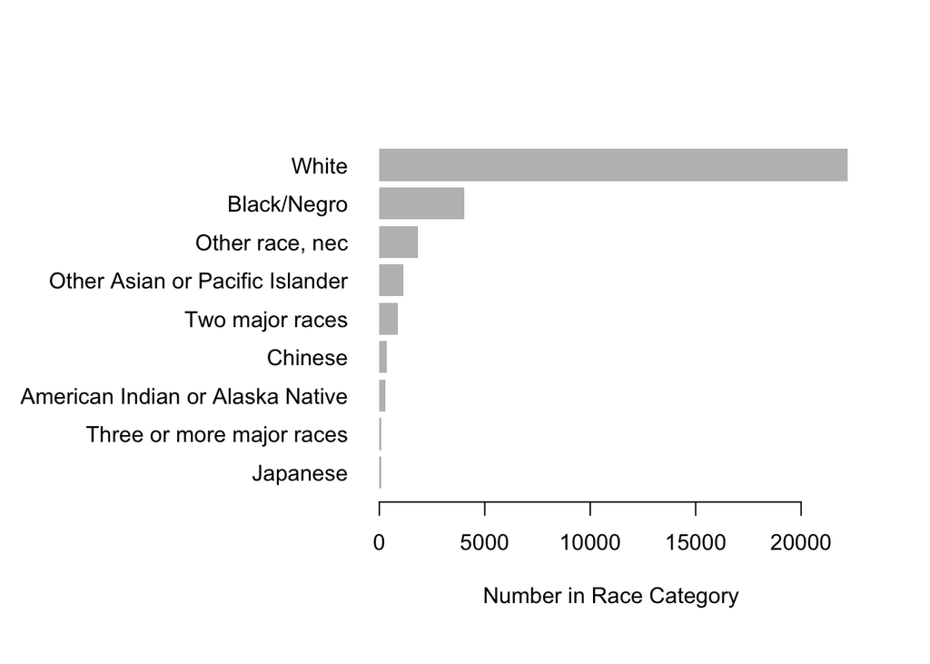

```r
par(oma = c(1, 10, 1, 1))
barplot(sort(tab_race), # sort numbers
        horiz = TRUE, # flip
        border = NA, # border is extraneous
        xlab = "Number in Race Category",
        bty = "n", # no box
        las = 1) # alignment of axis labels is horizontal
```

Notice that we applied the `sort()` function to order the bars in terms of their counts. The default ordering of a categorical variable / factor is alphabetical. Alphabetical ordering is uninformative and almost never the way you should order variables.

In ggplot you might do this by:

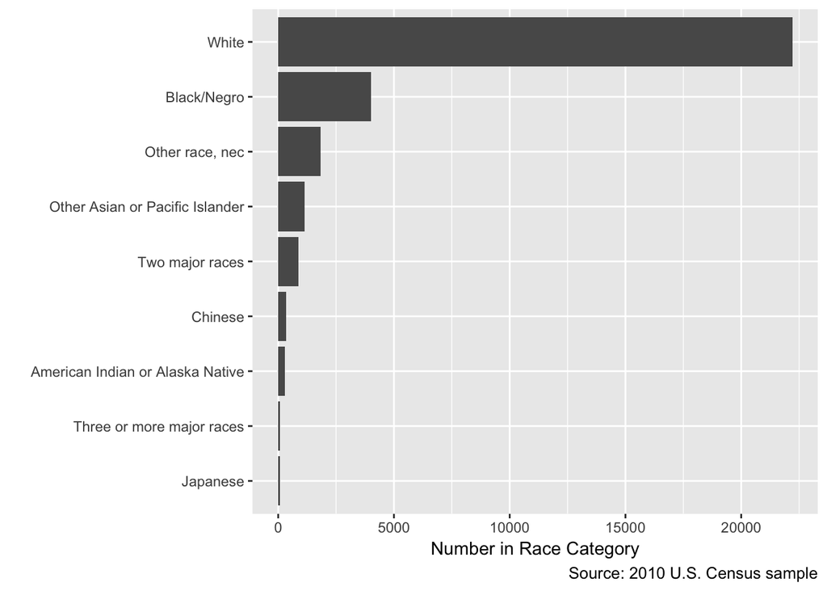

```r
grp_race_ordered <- arrange(grp_race, count) %>%
  mutate(race = forcats::as_factor(race))

ggplot(data = grp_race_ordered, aes(x = race, y = count)) +
  geom_col() +
  coord_flip() +
  labs(y = "Number in Race Category",
       x = "",
       caption = "Source: 2010 U.S. Census sample")
```

## Cross-tabs

A cross-tab is counting with two types of variables, and is a simple and powerful tool to show the relationship between multiple variables.

```r
xtab_race_state <- table(cen10$race, cen10$state)
dim(xtab_race_state)
```

```
## [1]  9 51
```

The `barplot` function kindly takes cross-tabs and figures out how to plot them:

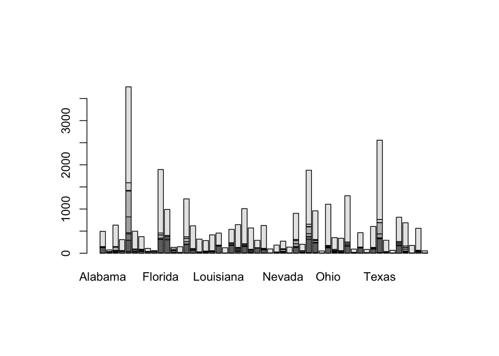

```r
par(oma = c(2,2,2,2))
barplot(xtab_race_state)
```

What if we care about proportions within states, rather than counts. We want to compare the racial composition of a small state (like Delaware) and a large state (like California).

One way to transform a table of counts to a table of proportions is the function `prop.table`. Be careful what you want to take proportions of – this is set by the `margin` argument. In R, the first margin (1) is *rows* and the second margin (2) is columns.

```r
ptab_race_state <- prop.table(xtab_race_state, margin = 2)
dim(ptab_race_state)
```

```
## [1]  9 51
```

Now we can plot these numbers. Let’s orient them horizontally:

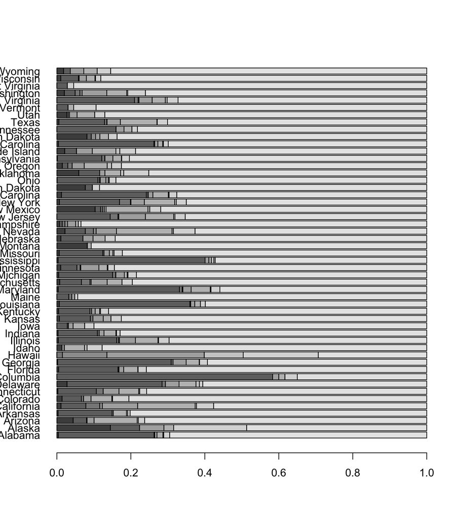

```r
barplot(ptab_race_state, horiz = TRUE, las = 1)
```

To make the same figure with `ggplot()`.

First, we want a count for each state $\times$ race combination. So group by those two factors and count how many observations are in each two-way categorization.

```r
grp_race_state <- cen10 %>%
  group_by(race, state) %>%
  summarize(count = n())
```

Can you tell from the code what `grp_race_state` will look like?

```r
# run on your own
grp_race_state
```

Now, we want to tell `ggplot2` something like the following: I want bars by state, where heights indicate racial groups. Each bar should be colored by the race. With some googling, you will get something like this

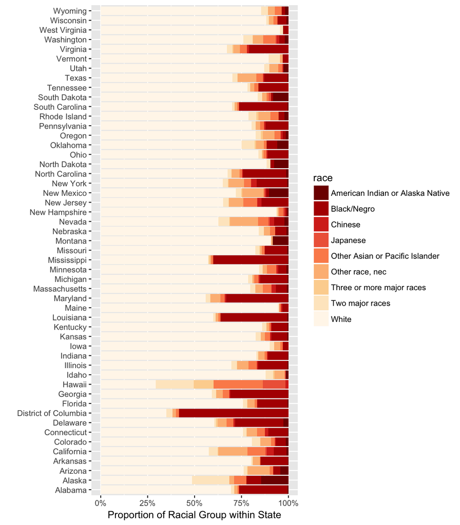

```r
ggplot(data = grp_race_state, aes(x = state, y = count,  fill = race)) +
  geom_col(position = "fill") + # the position is dertemined by the fill ae
  scale_fill_brewer(palette = "OrRd", direction = -1) + # choose palette
  coord_flip() + # flip axes
  scale_y_continuous(labels = percent) + # label numbers as percentage
  labs(y = "Proportion of Racial Group within State",
       x = "",
       source = "Source: 2010 Census  sample")
```

## Histograms

When our data is continuous rather than categorical, our first graphics will probably be a histogram.

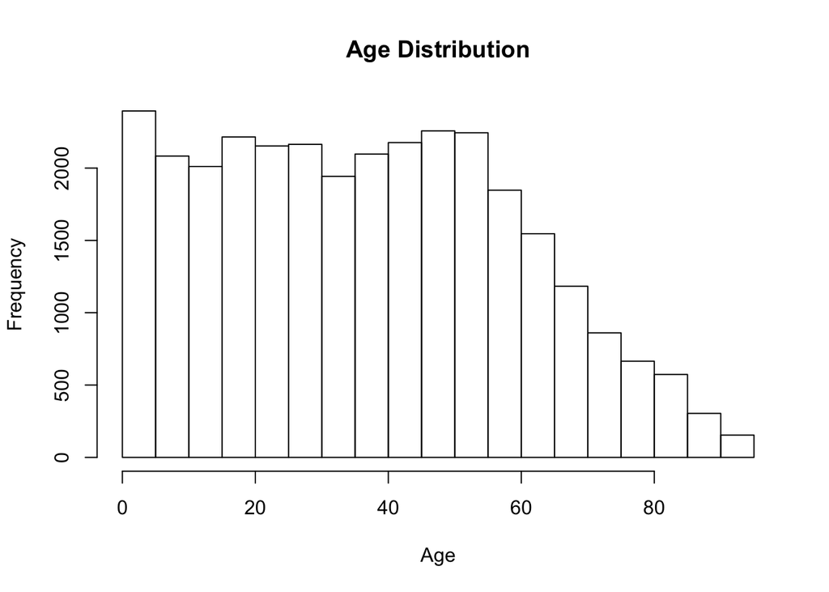

```r
hist(cen10$age, main = "Age Distribution", xlab = "Age")
```

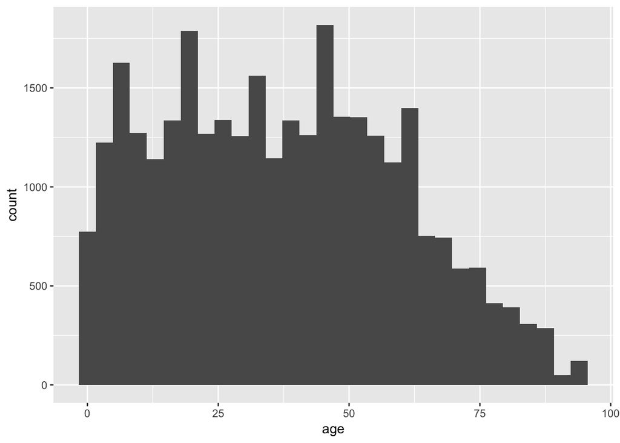

```r
ggplot(data = cen10, aes(x = age)) +
  geom_histogram()
```

# What is an object?

Now that we have covered some hands-on ways to use graphics, let’s go into some fundamentals of the R language.

Objects are abstract symbols in which you store data. Here we will create an object from `copy`, and assign `cen10` to it.

```r
copy <- cen10
```

This looks the same as the original dataset:

```r
copy
```

```
## # A tibble: 30,871 x 13
##     year  serial pernum                   region         state countyfips
##    <int>   <int>  <int>                    <chr>         <chr>      <int>
##  1  2010 8801316      4 Middle Atlantic Division      New York          0
##  2  2010 9800859      1  East North Central Div.          Ohio        103
##  3  2010 8685036      1        Mountain Division        Nevada          3
##  4  2010 6350851      3  East North Central Div.      Michigan          0
##  5  2010 6150669      2  South Atlantic Division      Maryland         33
##  6  2010 8102175      1     New England Division New Hampshire          0
##  7  2010 4057665      1  West North Central Div.          Iowa          0
##  8  2010 7029004      2  West North Central Div.      Missouri          0
##  9  2010 8162406      2 Middle Atlantic Division    New Jersey          3
## 10  2010 1117846      3         Pacific Division    California         37
## # ... with 30,861 more rows, and 7 more variables: city <chr>,
## #   cpuma0010 <int>, sex <chr>, age <int>, race <chr>, hhtype <chr>,
## #   relate <chr>
```

What happens if you do this next?

```r
copy <- ""
```

It got reassigned:

```r
copy
```

```
## [1] ""
```

## lists

Lists are one of the most generic and flexible type of object. You can make an empty list by the function `list()`

```r
my_list <- list()
my_list
```

```
## list()
```

And start filling it in. Slots on the list are invoked by double square brackets `[[]]`

```r
my_list[[1]] <- "contents of the first slot -- this is a string"
my_list[["slot 2"]] <- "contents of slot named slot 2"
my_list
```

```
## [[1]]
## [1] "contents of the first slot -- this is a string"
##
## $`slot 2`
## [1] "contents of slot named slot 2"
```

each slot can be anything. What are we doing here? We are defining the 1st slot of the list `my_list` to be a vector `c(1, 2, 3, 4, 5)`

```r
my_list[[1]] <- c(1, 2, 3, 4, 5)
```

You can even make nested lists. Let’s say we want the 1st slot of the list to be another list of three elements.

```r
my_list[[1]][[1]] <- "subitem 1 in slot 1 of my_list"
my_list[[1]][[2]] <- "subitem 1 in slot 2 of my_list"
my_list[[1]][[3]] <- "subitem 1 in slot 3 of my_list"

my_list
```

```
## [[1]]
## [1] "subitem 1 in slot 1 of my_list" "subitem 1 in slot 2 of my_list"
## [3] "subitem 1 in slot 3 of my_list" "4"
## [5] "5"
##
## $`slot 2`
## [1] "contents of slot named slot 2"
```

## Making your own objects

We’ve covered one type of object, which is a list. You saw it was quite flexible. How many types of objects are there?

There are an infinite number of objects, because people make their own class of object. You can detect the type of the object (the class) by the function `class`

What is type of object is `cen10`?

```r
class(cen10)
```

```
## [1] "tbl_df"     "tbl"        "data.frame"
```

What about this text?

```r
class("some random text")
```

```
## [1] "character"
```

To change or create the class of any object, you can *assign* it. To do this, assign the name of your class to character to an object’s `class()`.

We can start from a simple list. For example, say we wanted to store data about pokemon. Because there is no pre-made package for this, we decide to make our own class.

```r
pikachu <- list(name = "Pikachu",
                number = 25,
                type = "Electric",
                color = "Yellow")
```

and we can give it any class name we want.

```r
class(pikachu) <- "Pokemon"
```

## Seeing R through objects

Most of the R objects that you will see as you advance are their own objects. For example, here’s a linear regression object (which you will learn more about in Gov 2000):

```r
ols <- lm(mpg ~ wt + vs + gear + carb, mtcars)
class(ols)
```

```
## [1] "lm"
```

Anything can be an object! Even graphs (in `ggplot`) can be assigned, re-assigned, and edited.

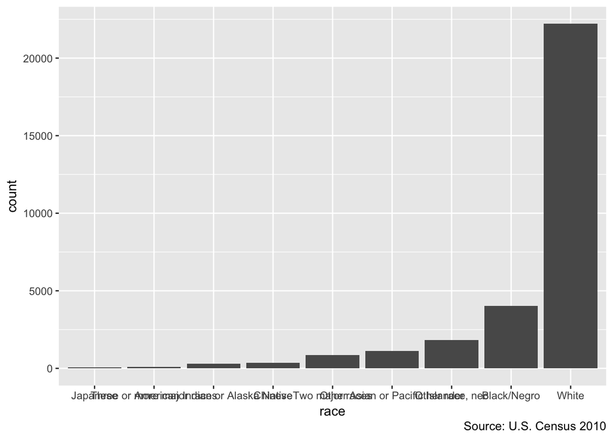

```r
gg_tab <- ggplot(data = grp_race_ordered) +
  aes(x = race, y = count) +
  geom_col() +
  labs(caption = "Source: U.S. Census 2010")
gg_tab
```

You can change the orientation

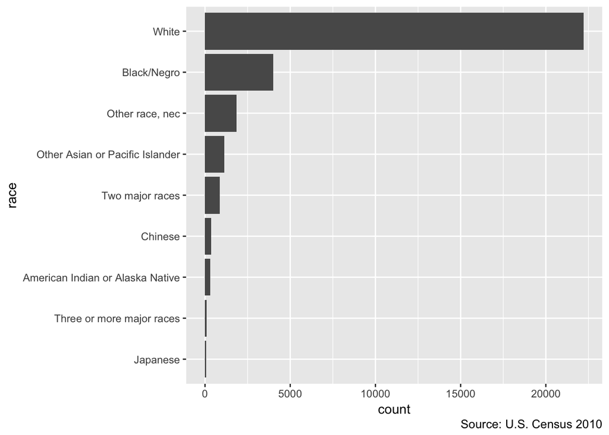

```r
gg_tab + coord_flip()
```

Or even change the variables altogether, while still maintaining the same format.

## Parsing an object by `str()s`

It can be hard to understand an `R` object because it’s contents are unknown. The function `str`, short for structure, is a quick way to look into the innards of an object

```r
str(my_list)
```

```
## List of 2
##  $       : chr [1:5] "subitem 1 in slot 1 of my_list" "subitem 1 in slot 2 of my_list" "subitem 1 in slot 3 of my_list" "4" ...
##  $ slot 2: chr "contents of slot named slot 2"
```

Same for the object we just made

```r
str(pikachu)
```

```
## List of 4
##  $ name  : chr "Pikachu"
##  $ number: num 25
##  $ type  : chr "Electric"
##  $ color : chr "Yellow"
##  - attr(*, "class")= chr "Pokemon"
```

What does a `ggplot` object look like? Very complicated, but at least you can see it:

```r
# enter this on your console
str(gg_tab)
```

# Types of variables

In the social science we often analyze variables. As you saw in the tutorial, different types of variables require different care.

A key link with what we just learned is that variables are also types of R objects.

## scalars

One number. How many people did we count in our Census sample?

```r
nrow(cen10)
```

```
## [1] 30871
```

Question: What proportion of our census sample is Native American? This number is also a scalar

```r
# Enter yourself
```

Hint: you can use the function `mean()` to calcualte the sample mean. The sample proportion is the mean of a sequence of number, where your event of interest is a 1 (or `TRUE`) and others are 0 (or `FALSE`).

## numeric vectors

A sequence of numbers.

```r
grp_race_ordered$count
```

```
## [1]    77    88   295   354   869  1129  1839  4013 22207
```

```r
head(cen10$age)
```

```
## [1]  8 24 37 12 18 50
```

## characters (aka strings)

This can be just one stretch of characters

```r
my_name <- "Shiro"
my_name
```

```
## [1] "Shiro"
```

or more characters. Notice here that there’s a difference between a vector of individual characters and a length-one object of characters.

```r
my_name_letters <- c("S", "h", "i", "r", "o")
my_name_letters
```

```
## [1] "S" "h" "i" "r" "o"
```

Finally, remember that lower vs. upper case matters in R!

```r
my_name2 <- "shiro"
my_name == my_name2
```

```
## [1] FALSE
```

## matricies

Matrices are rectangular structures of numbers (they have to be numbers, and they can’t be characters).

A cross-tab can be considered a matrix:

```r
table(cen10$race, cen10$sex)
```

```
##
##                                    Female  Male
##   American Indian or Alaska Native    142   153
##   Black/Negro                        2070  1943
##   Chinese                             192   162
##   Japanese                             51    26
##   Other Asian or Pacific Islander     587   542
##   Other race, nec                     877   962
##   Three or more major races            37    51
##   Two major races                     443   426
##   White                             11252 10955
```

But a subset of your data – individual values– can be considered a matrix too.

```r
cen10[1:20, c("year", "age")]
```

```
## # A tibble: 20 x 2
##     year   age
##    <int> <int>
##  1  2010     8
##  2  2010    24
##  3  2010    37
##  4  2010    12
##  5  2010    18
##  6  2010    50
##  7  2010    51
##  8  2010    41
##  9  2010    62
## 10  2010    25
## 11  2010    23
## 12  2010    66
## 13  2010    57
## 14  2010    73
## 15  2010    43
## 16  2010    29
## 17  2010     8
## 18  2010    78
## 19  2010    10
## 20  2010     9
```

A vector is a special type of matrix with only one column or only one row (more on this in tomorrow’s linear algebra session).

```r
cen10[1:10, c("age")]
```

```
## # A tibble: 10 x 1
##      age
##    <int>
##  1     8
##  2    24
##  3    37
##  4    12
##  5    18
##  6    50
##  7    51
##  8    41
##  9    62
## 10    25
```

## data frames

You can think of data frames maybe as matrices-plus, because a column can take on characters as well as numbers. As we just saw, this is often useful for real data analyses.

```r
cen10
```

```
## # A tibble: 30,871 x 13
##     year  serial pernum                   region         state countyfips
##    <int>   <int>  <int>                    <chr>         <chr>      <int>
##  1  2010 8801316      4 Middle Atlantic Division      New York          0
##  2  2010 9800859      1  East North Central Div.          Ohio        103
##  3  2010 8685036      1        Mountain Division        Nevada          3
##  4  2010 6350851      3  East North Central Div.      Michigan          0
##  5  2010 6150669      2  South Atlantic Division      Maryland         33
##  6  2010 8102175      1     New England Division New Hampshire          0
##  7  2010 4057665      1  West North Central Div.          Iowa          0
##  8  2010 7029004      2  West North Central Div.      Missouri          0
##  9  2010 8162406      2 Middle Atlantic Division    New Jersey          3
## 10  2010 1117846      3         Pacific Division    California         37
## # ... with 30,861 more rows, and 7 more variables: city <chr>,
## #   cpuma0010 <int>, sex <chr>, age <int>, race <chr>, hhtype <chr>,
## #   relate <chr>
```

Another way to think about data frames is that it is a type of list. Try the `str()` code below and notice how it is organized in slots. Each slot is a vector. They can be vectors of numbers or characters.

```r
# enter this on your console
str(cen10)
```

## Extracting variables from lists

Often you want to inspect one variable of you r dataset. There are multiple ways to do this.

1. with the single-square bracket, as in a matrix:

```r
cen10[, "race"]
```

```
## # A tibble: 30,871 x 1
##           race
##          <chr>
##  1       White
##  2       White
##  3       White
##  4       White
##  5 Black/Negro
##  6       White
##  7       White
##  8       White
##  9       White
## 10       White
## # ... with 30,861 more rows
```

2. which you can also refer to by the number of the column

```r
cen10[, 11]
```

```
## # A tibble: 30,871 x 1
##           race
##          <chr>
##  1       White
##  2       White
##  3       White
##  4       White
##  5 Black/Negro
##  6       White
##  7       White
##  8       White
##  9       White
## 10       White
## # ... with 30,861 more rows
```

3. with double-square brackets as in a data frame

```r
head(cen10[["race"]])
```

```
## [1] "White"       "White"       "White"       "White"       "Black/Negro"
## [6] "White"
```

4. and with the dollar-sign `$`

```r
head(cen10$race)
```

```
## [1] "White"       "White"       "White"       "White"       "Black/Negro"
## [6] "White"
```

5. in the `dplyr` package, you can `select` multiple variables like this:

```r
cen10 %>% select(race, state, age)
```

```
## # A tibble: 30,871 x 3
##           race         state   age
##          <chr>         <chr> <int>
##  1       White      New York     8
##  2       White          Ohio    24
##  3       White        Nevada    37
##  4       White      Michigan    12
##  5 Black/Negro      Maryland    18
##  6       White New Hampshire    50
##  7       White          Iowa    51
##  8       White      Missouri    41
##  9       White    New Jersey    62
## 10       White    California    25
## # ... with 30,861 more rows
```

# What is a function?

Most of what we do in R is executing a function. `read_csv()`, `nrow()`, `ggplot()` .. pretty much anything with a parentheses is a function. And even things like `<-` and `[` are functions as well.

A function is a set of instructions with specified ingredients. It takes an **input**, then **manipulates** it – changes it in some way – and then returns the manipulated product.

One way to see what a function actually does is to enter it without parentheses.

```r
# enter this on your console
table
```

You’ll notice that functions contain other functions. *wrapper* functions are functions that “wrap around” existing functions. This sounds redundant, but it’s an important feature of programming. If you find yourself repeating a command more than two times, you should make your own function, rather than writing the same type of code.

## Write your own function

It’s worth remembering the basic structure of a function. You create a new function, call it `my_fun` by this:

```r
my_fun <- function() {

}
```

If we wanted to generate a function that computed the number of men in your data, what would that look like?

```r
count_men <- function(data) {

  nmen <- sum(data$sex == "Male")

  return(nmen)
}
```

Then all we need to do is feed this function a dataset

```r
count_men(cen10)
```

```
## [1] 15220
```

The point of a function is that you can use it again and again without typing up the set of constituent manipulations. So, what if we wanted to figure out the number of men in California?

```r
count_men(filter(cen10, state == "California"))
```

```
## [1] 1876
```

Let’s go one step further. What if we want to know the proportion of non-whites in a state, just by entering the name of the state? There’s multiple ways to do it, but it could look something like this

```r
nw_in_state <- function(data, state) {
  s.subset <- filter(data, state == state)

  total.s <- nrow(s.subset)
  nw.s <- sum(s.subset$race != "White")

  nw.s / total.s
}
```

The last line is what gets generated from the function. To be more explicit you can wrap the last line around `return()`. (as in `return(nw.s/total.s`). `return()` is used when you want to break out of a function in the middle of it and not wait till the last line.

Try it on your favorite state!

```r
nw_in_state(cen10, "Alabama")
```

```
## [1] 0.2806517
```

Exercise. Try making your own function, `asians_in_state`, that will give you the number of `Chinese`, `Japanese`, and `Other Asian or Pacific Islander` people in a given state.

```r
# Enter on your own
```

# What is a package?

You can think of a package as a suite of functions that other people have already built for you to make your life easier.

```r
help(package = "ggplot2")
```

To use a package, you need to do two things: (1) install it, and then (2) load it.

Installing is a one-time thing

```r
install.packages("ggplot2")
```

But you need to load each time you start a R instance. So always keep these commands on a script.

```r
library(ggplot2)
```

In `rstudio.cloud`, we already installed a set of packages for you. But when you start your own R instance, you need to have installed the package at some point.

# Review Exercises

In the time remaining, try the following exercises. Order doesn’t matter.

## Exercise 1: Make your own graphic

Make a graphic from the census data that tells us something interesting about the U.S. 2010 population.

```r
# Enter yourself
```

## Exercise 2: Counting CVAP

A issue raised in Persily’s article is that the full-count U.S. Census does not record whether the residents are citizens of the United States[^7]. Instead, this question is asked in a survey, the American Community Survey. The two are fundamentally different exercises: the Census counts everyone by definition, a survey samples its data. Load the 1 percent sample of the 2015 ACS (`acs2015_1percent.csv`, in the `input` folder) and give an estimate of the proportion of a state’s ACS respondents that are reportedly U.S. citizens.

```r
# Enter yourself
```

## Exercise 3: Write your own function

Write your own function that makes some task of data analysis simpler. Ideally, it would be a function that helps you do either of the previous tasks in fewer lines of code.

```r
# Enter yourself
```

# Tell us about this session.

This is day 1 and we covered a lot of material. Some of you might have found this completely new; others not so. Please click through this survey before you leave so we can adjust accordingly on the next few days.

https://harvard.az1.qualtrics.com/jfe/form/SV_6D1PZiZxFY0Kfzf

[^1]: [Persily, Nathaniel. 2011. “The Law of the Census: How to Count, What to Count, Whom to Count, and Where to Count Them.” *Cardozo Law Review* 32(3): 755–91.](http://cardozolawreview.com/Joomla1.5/content/32-3/Persily.32-3.pdf)
[^2]: [Hochschild, Jennifer L., and Brenna Marea Powell. 2008. “Racial Reorganization and the United States Census 1850–1930: Mulattoes, Half-Breeds, Mixed Parentage, Hindoos, and the Mexican Race.” *Studies in American Political Development* 22(1): 59–96.](https://dash.harvard.edu/bitstream/handle/1/3153295/hoschschild_racialreorganization.pdf?sequence=2)
[^3]: [Ruggles, Steven, Katie Genadek, Ronald Goeken, Josiah Grover, and Matthew Sobek. 2015. Integrated Public Use Microdata Series: Version 6.0 dataset](http://doi.org/10.18128/D010.V6.0)
[^4]: The 2010 Census reported 308,745,539. [Wikipedia](https://en.wikipedia.org/wiki/2010_United_States_Census)
[^5]: [Kastellec, Jonathan P., and Eduardo L. Leoni. 2007. “Using Graphs Instead of Tables in Political Science.”" *Perspectives on Politics* 5 (4): 755–71.](http://www.princeton.edu/~jkastell/Tables2Graphs/graphs.pdf)
[^6]: Tufte, Edward. *The Visual Display of Quantitative Information*
[^7]: Here is that argument of his again, more recently in the popular press. [“The Mysterious Number of American Citizens”. June 2, 2015. *POLITICO*](http://www.politico.com/magazine/story/2015/06/the-supreme-courts-big-data-problem-118568)